Krzysztof Ślot

Uczenie nienadzorowane

Materiały wykładowe: wykład 1

# Uczenie nienadzorowane w sieciach neuronowych

Uczenie nienadzorowane korzysta z przykładów, dla których nie posiadamy etykiet, czyli wiedzy o ich przynależności do kategorii (w przypadku klasyfikacji) lub konkretnej wartości oceniającej ich stan (w przypadku regresji). Uczenie nienadzorowane jest jednocześnie najbardziej elementarną formą adekwatną w przypadku biologii - wprowadzony wcześniej schemat uczenia nadzorowanego, gdzie istnieje możliwość bieżącej oceny reakcji na dane wejściowe, w odniesieniu do bilogii jest bardzo wątpliwy (komórka nerwowa nie posiada oceniającego jej działanie 'nauczyciela').

## Uczenie pojedynczego neuronu

Fundamentem zrozumienia mechanizmów uczenia komórek nerwowych były eksperymenty przeprowadzane w XIX w., przede wszystkim przez Pawłowa (wprowadziły one do słownika np. termin odruchów warunkowych). Matematyczny opis procesu uczenia został jednak przedstawiony dopiero przez Donalda Hebba, w latach 50-tych XX w., gdy możliwości techniczne pozwoliły na powiązanie obserwacji jakościowych z badaniami na poziomie komórkowym.

### Reguła Hebba

Reguła Hebba, stanowi odzwierciedlenie mechanizmu zachodzącego podczas uczenia - połączenia synaptyczne wzmacniają się w funkcji zgodności między sygnałem wejściowym i sygnałem wyjściowym komórki (ponieważ dla większości komórek w układzie nerwowym sygnały wejściowe to sygnały wyjściowe innych komórek, lapidarny sposób wyrażenia reguły to: 'neurons that synchronously fire, wire'). Załóżmy, że na wejście komórki podawany jest wektor $\mathbf{x} = [x^j_1 ... x^j_n]$, a wynikiem przetworzenia tego wektora jest $y$. Korekta wagi $i$ neuronu, zgodnie z regułą Hebba, jest określona jako:

\begin{equation} \Delta w_i = \eta x_i y \end{equation}

gdzie $\eta$ to nieujemny współczynnik proporcjonalności. Korekta wszystkich wag neuronu to:

\begin{equation} \Delta \mathbf{w} = \eta \mathbf{x} y \end{equation}

Załóżmy, że neuron jest liniowy, wtedy:

\begin{equation} y = \sum_{i=1}^n w_i x_i = (\mathbf{x}^t)^T \mathbf{w}^{t=0}, \end{equation}

gdzie $\mathbf{w}^{t=0}$ to początkowa wartość wektora wag, a iteracyjna procedura uczenia dla prezentacji wektorów w kolejnych chwilach $t$ przybiera postać:

\begin{equation} \Delta \mathbf{w}^t = \eta \mathbf{x}^t (\mathbf{x}^t)^T \mathbf{w}^t \end{equation}

Jeśli neurony są nieliniowe, czyli $s = f(\mathbf{x}^T \mathbf{w}), odpowiednia zależność na korekty wag przyjmuje postać:

\begin{equation} \Delta \mathbf{w}^t = \eta \mathbf{x}^t f( (\mathbf{x}^t)^T \mathbf{w}^t) \end{equation}

Jeżeli zbiór treningowy zawiera $m$ przykładów, trening można przeprowadzić w schemacie 'wsadowym ('batch learning'), a więc korekta wag może być efektem średniej z korekt wywoływanych przez poszczególne elementy zbioru:

\begin{equation} \Delta \mathbf{w} = \frac{1}{m} \left( \sum_{j=1}^m \eta \mathbf{x}^j (\mathbf{x}^j)^T \right) \mathbf{w}_0 \end{equation}

Wyrażenie w nawiasie to macierz kowariancji próbek, więc reguła uczenia może być zapisana jako:

\begin{equation} \Delta \mathbf{w} = \eta \mathbf{C} \mathbf{w}_0 \end{equation}

Oznacza to, że korekty wag są powiązane z korelacjami, jakie występują między komponentami próbek. Jeżeli między komponentami występują silne korelacje, będzie to uwypuklone w wypadkowych wartościach wag dla tych komponentów. Oznacza to, że neurony uczą się związków (korelacji), jakie występują między cechami występującymi w danych uczących.

Przykład

Załóżmy, że liniowy neuron ma trzy wejścia, na których pojawiają się liczby, odpowiadające komponentom koloru R, G i B. Trening neuronu odbywa się zgodnie z regułą Hebba - neuron 'widzi' kolejne próbki, ale nie dostaje poza tym żadnej dodatkowej informacji.

```python
import numpy as np

# zbiór uczący - po 50 przykładów koloru żółtego (mieszanka czerwieni i zieleni)
# i 'cyjanowego' (niebieski-zielony). UWAGA: aby nie komplikować kodu, nie ma
# sprawdzania, czy wartość komponentu leży w zakresie [0..255]
m = 100 # całkowita liczba przykładów
d = 3 # długość wektora wejściowego
W0 = np.random.standard_normal(d+1) # wektor wag początkowych dla wejść RGB + wyraz wolny
X = np.zeros((m,d+1), dtype=int) # macierz przykładów

# próbki żółte
X[:int(m/2),0:2] = np.random.normal(200,10,size=(int(m/2),2)).astype(int) # komponenty R i G dla próbek żółtych
X[:int(m/2),2] = np.random.normal(20,5,size=int(m/2)).astype(int) # komponenty B dla próbek żółtych

# próbki cyjan
X[int(m/2):,1:3] = np.random.normal(200,10,size=(int(m/2),2)).astype(int) # komponenty G i B
X[int(m/2):,0] = np.random.normal(20,5,size=int(m/2)).astype(int) # komponenty R

X[:,3] = -1

# ------------------------------------------------------------------------------------------------------------
# ---------------  Uczenie regułą Hebba

# Wariant 1: sekwencyjna prezentacja r losowo wybieranych próbek
W = np.copy(W0)
r = 200
for i in range(r):
    x = X[np.random.randint(0,high=m),:]
    W += x*np.dot(x,W)
    W /= np.linalg.norm(W) # normalizacja, by wartości wektora nie rosły lawinowo
print("Wynik uczenia 1: " + str(W))
# Wariant drugi: wykorzystanie macierzy korelacji próbek

C = np.dot(X.T,X)
W1 = np.dot(C,W0)/m

print("Wynik uczenia 2: " + str(W1/np.linalg.norm(W1)))
print('Macierz kowariancji próbek')
print(C/np.linalg.norm(C))
```

```
Wynik uczenia 1: [ 0.0893697   0.7113857   0.69708727 -0.0035748 ]
Wynik uczenia 2: [ 0.44937519  0.79241316  0.41246512 -0.00398029]
Macierz kowariancji próbek
[[ 3.07383287e-01  3.32460435e-01  5.75952174e-02 -1.67636071e-03]
 [ 3.32460435e-01  6.07352002e-01  3.29553037e-01 -3.05470858e-03]
 [ 5.75952174e-02  3.29553037e-01  3.02827573e-01 -1.66295475e-03]
 [-1.67636071e-03 -3.05470858e-03 -1.66295475e-03  1.54091434e-05]]
```

Wniosek 1: Po zakończeniu procesu nauki, wagi neuronu mają wyraźną strukturę (dwie są porównywalne, trzecia - dużo mniejsza).

Pytanie: co z tego może wynikać? Odpowiedź na to pytanie daje analiza wyników przetwarzania danych w nauczonym neuronie.

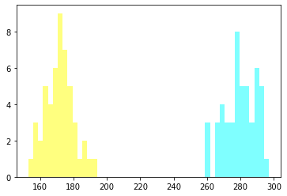

```python
import matplotlib.pyplot as plt

# %% Analiza efektów uczenia

# prezentacja próbek żółtych
idx = np.argwhere(X[:,0]>100)  # próbki żółte mają składową R>100
YY = np.dot(X[idx,:],W)

# prezentacja próbek cyjanowych
idx = np.argwhere(X[:,0]<100)  # próbki żółte mają składową R<100
YC = np.dot(X[idx,:],W)

bins = np.linspace(int(np.min((np.min(YY), np.min(YC)))),
                   int(np.max((np.max(YY), np.max(YC)))), 50)
plt.hist(YY, bins=bins, alpha=0.5, color='yellow')
plt.hist(YC, bins=bins, alpha=0.5, color='cyan')
```